# Household Consumption Regression Project

**INSEAD MBA - Big Data and Analytics for Business Course Project**

**Jakub Parusinski, Neelabh Chaturvedi, Onur Candar | February 2015**

### Project Details

In fast growth countries, household consumption can boost the GDP growth. In this project, we want to understand which variables are influencing the household consumption of a country.

We identified several factors that might influence the household consumption:

- Demographics - Population, Age, Education and Urban Population
- Macroeconomic Indicators - Inflation
- Infrastructure Improvements - Shopping Mall Projects and Gross Leasable Area
- Labor Statistics - Minimum Wage and Unemployment
- Social Indicators - Happiness and Poverty

Since any one of them may have an important impact, we gathered data on all of them at this early stage in the process.

**The Data**

In this project, we used Turkey as an example. However, same model can be applied on any country, by feeding the model with related country's data.

Data is taken from Turkey's National Statistics Agency - TURKSTAT.

A list of the variables is given below:

1. Year - Year of Data Point
2. Population - Total population of Turkey (in Millions)
3. MedianAge - Median Age of the Turkish Population (Percentage * 100)
4. IlleteracyRate - Overall Illiteracy Percentage of the Country (Multiplied by 100)
5. Inflation - Annualized Inflation Rate (Percentage * 100)
6. Unemployment - Percentage of Unemployment (Percentage * 100)
7. MinimumWage - Minimum Monthly Wage in Turkish Liras (Nominal)
8. PercentageOfUnderprivilaged - Percentage of Population Living for Under $4 per Day (Multiplied by 100)
9. OverallHappiness - Total percentage of respondents who responded “Happy” and “Very Happy” to National Happiness Survey (Multiplied by 100)
10. GLA - Gross Leasable Shopping Center Area
11. ShoppingMall - Number of Shopping Malls
12. UrbanPopulation - Percentage of Urban Population (Multiplied by 100)

**The Analysis**

Let's first see some summary statistics.

Summary Statistics

|  | TotalConsumption | Year | MedianAge | UrbanPopulation | MinimumWage | Inflation | Unemployment | PercentageOfUnderprivilaged | OverallHappiness | GLA | ShoppingMall | IlleteracyRate |
| --- | --- | --- | --- | --- | --- | --- | --- | --- | --- | --- | --- | --- |
| 1 | Min. : 238.4 | Min. :2002 | Min. :24.80 | Min. :64.90 | Min. : 250.0 | Min. : 6.000 | Min. : 8.500 | Min. : 2.100 | Min. :54.30 | Min. : 1.760 | Min. : 60.0 | Min. : 4.000 |
| 2 | 1st Qu.: 448.7 | 1st Qu.:2005 | 1st Qu.:25.90 | 1st Qu.:67.38 | 1st Qu.: 472.5 | 1st Qu.: 7.000 | 1st Qu.: 9.050 | 1st Qu.: 3.475 | 1st Qu.:57.50 | 1st Qu.: 2.360 | 1st Qu.:102.8 | 1st Qu.: 5.675 |
| 3 | Median : 632.6 | Median :2008 | Median :28.40 | Median :72.75 | Median : 611.5 | Median : 8.550 | Median : 9.850 | Median : 7.600 | Median :58.85 | Median : 4.410 | Median :188.0 | Median : 7.900 |
| 4 | Mean : 643.5 | Mean :2008 | Mean :27.75 | Mean :73.02 | Mean : 636.4 | Mean : 9.908 | Mean : 9.975 | Mean :11.267 | Mean :58.72 | Mean : 4.900 | Mean :192.4 | Mean : 8.183 |
| 5 | 3rd Qu.: 821.8 | 3rd Qu.:2010 | 3rd Qu.:29.32 | 3rd Qu.:76.42 | 3rd Qu.: 756.8 | 3rd Qu.: 9.550 | 3rd Qu.:10.575 | 3rd Qu.:17.525 | 3rd Qu.:60.40 | 3rd Qu.: 6.775 | 3rd Qu.:271.8 | 3rd Qu.:10.775 |
| 6 | Max. :1109.4 | Max. :2013 | Max. :30.40 | Max. :91.30 | Max. :1134.0 | Max. :29.800 | Max. :12.000 | Max. :30.300 | Max. :62.10 | Max. :10.700 | Max. :353.0 | Max. :12.700 |

This is a histogram of our dependent variable TotalConsumption:

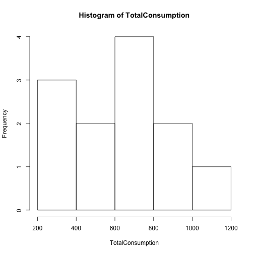

Let's now see the correlation between all our variables:

|  | Year | MedianAge | UrbanPopulation | MinimumWage | Inflation | Unemployment | PercentageOfUnderprivilaged | OverallHappiness | GLA | ShoppingMall | IlleteracyRate | TotalConsumption |
| --- | --- | --- | --- | --- | --- | --- | --- | --- | --- | --- | --- | --- |
| Year | 1.00 | 0.98 | 0.91 | 0.98 | -0.56 | -0.34 | -0.95 | 0.39 | 0.97 | 0.99 | -0.99 | 0.99 |
| MedianAge | 0.98 | 1.00 | 0.88 | 0.94 | -0.54 | -0.27 | -0.96 | 0.36 | 0.94 | 0.98 | -0.99 | 0.96 |
| UrbanPopulation | 0.91 | 0.88 | 1.00 | 0.93 | -0.42 | -0.22 | -0.80 | 0.25 | 0.96 | 0.93 | -0.88 | 0.92 |
| MinimumWage | 0.98 | 0.94 | 0.93 | 1.00 | -0.54 | -0.39 | -0.89 | 0.38 | 0.97 | 0.97 | -0.97 | 0.99 |
| Inflation | -0.56 | -0.54 | -0.42 | -0.54 | 1.00 | 0.09 | 0.69 | -0.20 | -0.42 | -0.50 | 0.53 | -0.54 |
| Unemployment | -0.34 | -0.27 | -0.22 | -0.39 | 0.09 | 1.00 | 0.23 | -0.78 | -0.34 | -0.30 | 0.35 | -0.41 |
| PercentageOfUnderprivilaged | -0.95 | -0.96 | -0.80 | -0.89 | 0.69 | 0.23 | 1.00 | -0.28 | -0.85 | -0.92 | 0.95 | -0.92 |
| OverallHappiness | 0.39 | 0.36 | 0.25 | 0.38 | -0.20 | -0.78 | -0.28 | 1.00 | 0.41 | 0.39 | -0.43 | 0.44 |
| GLA | 0.97 | 0.94 | 0.96 | 0.97 | -0.42 | -0.34 | -0.85 | 0.41 | 1.00 | 0.98 | -0.96 | 0.98 |
| ShoppingMall | 0.99 | 0.98 | 0.93 | 0.97 | -0.50 | -0.30 | -0.92 | 0.39 | 0.98 | 1.00 | -0.99 | 0.99 |
| IlleteracyRate | -0.99 | -0.99 | -0.88 | -0.97 | 0.53 | 0.35 | 0.95 | -0.43 | -0.96 | -0.99 | 1.00 | -0.99 |
| TotalConsumption | 0.99 | 0.96 | 0.92 | 0.99 | -0.54 | -0.41 | -0.92 | 0.44 | 0.98 | 0.99 | -0.99 | 1.00 |

and maybe a plot between our dependent variable and, say, the first variable Year:

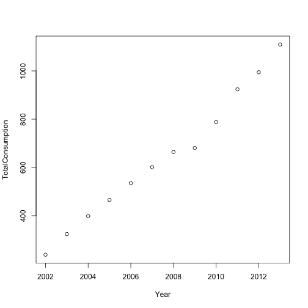

**Iterations**

Here is the correlation matrix between our **final variables**:

|  | MinimumWage | PercentageOfUnderprivilaged | OverallHappiness | TotalConsumption |
| --- | --- | --- | --- | --- |
| MinimumWage | 1.00 | -0.89 | 0.38 | 0.99 |
| PercentageOfUnderprivilaged | -0.89 | 1.00 | -0.28 | -0.92 |
| OverallHappiness | 0.38 | -0.28 | 1.00 | 0.44 |
| TotalConsumption | 0.99 | -0.92 | 0.44 | 1.00 |

### Regression Model

Our final **regression model** after the iterations is as the following:

TotalConsumption = b1*MinimumWage + b2*PercentageOfUnderprivilaged + b3*OverallHappiness

Let's see now the regression output for our choice of dependent and independent variables:

Regression Analysis - Dependent variableTotalConsumption

|  | Estimate | Std. Error | t value | Pr(>\|t\|) |
| --- | --- | --- | --- | --- |
| (Intercept) | -372.9993 | 206.9321 | -1.80 | 0.1091 |
| MinimumWage | 0.8046 | 0.0676 | 11.91 | 0.0000 |
| PercentageOfUnderprivilaged | -5.3258 | 1.8137 | -2.94 | 0.0188 |
| OverallHappiness | 9.6134 | 3.6496 | 2.63 | 0.0300 |

Residual standard error: 25.7088076 on 8 degrees of freedom  
Multiple R-squared: 0.9934952 , Adjusted R-squared: 0.9910559  
F-statistic: 407.2847579 on 3 and 8  
p-value: 4.3945347 × 10<sup>-9</sup>

**Residual Analysis**

Let's look now at the residuals. Here are some plots and statistics.

Of course we can make various plots of the residuals to “spot” (visually for now) and heteroskedasticity or autocorrelation. For example this is the plot of the residuals against the dependent variable TotalConsumption:

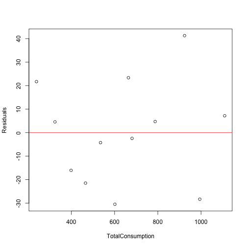

or the histogram of the residuals:

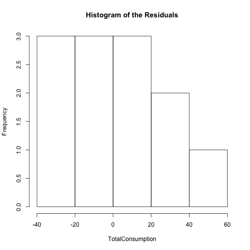

### Interpretation

According to our model, 3 independent variables - Minimum Wage, Percentage of Underprivileged among the Population, and Overall Happiness of the Society - explains the Total Consumptions.

These three variables, first addressing the increase in purchasing power, second suggesting decrease in income inequality and poverty, and third explaining the positive outlook of the society explains the growth of household consumption.

However there are several problems which needs further studies to resolve:

1- Minimum Wage and Percentage of Underprivileged are highly correlated, leading to Multicolinerity in the model. To increase the significance of the model, we decided to keep both variables in the model. By introduction of new independent variables, problem might be solved.

Using this code, generated on R, it is possible to change the data set, introduce new variables, increase the sample size and re-run the application.